# Difference-in-Differences Example: Kiel Housing Data

# Introduction

In this document we illustrate a **Difference-in-Differences (DiD)** approach using the `kielmc` dataset from the **wooldridge** package.

The dataset studies housing prices in Kiel, Wisconsin, before and after the construction of a **municipal incinerator** (waste incineration plant). The main question is whether proximity to the incinerator reduced house prices.

Key variables in the dataset:

- `rprice`: real housing price
- `nearinc`: indicator equal to 1 if the house is near the incinerator
- `year`: year of sale (1978 or 1981)
- `rooms`: number of rooms
- `baths`: number of bathrooms
- `larea`: log of house area
- `lland`: log of land area

The incinerator was announced between the two observed years. Houses **near the incinerator** form the treatment group, while houses **far away** serve as the control group.

The Difference-in-Differences strategy compares:

- price changes over time
- between houses near and far from the incinerator

# Load dependencies and data

```r
library(tidyverse)
library(modelsummary)
library(wooldridge)
library(knitr)

df <- wooldridge::kielmc
```

# Summary statistics

We start with summary statistics to understand the structure of the data.

```r
summary_table <- df %>%
  summarise(
    observations = n(),
    mean_price = mean(rprice, na.rm = TRUE),
    sd_price = sd(rprice, na.rm = TRUE),
    mean_rooms = mean(rooms, na.rm = TRUE),
    mean_baths = mean(baths, na.rm = TRUE)
  )

kable(summary_table, caption = "Basic Summary Statistics")
```

Basic Summary Statistics

| observations | mean_price | sd_price | mean_rooms | mean_baths |
| --- | --- | --- | --- | --- |
| 321 | 83721.36 | 33118.79 | 6.58567 | 2.339564 |

# Define treatment and post variables

For a DiD design we need two key variables:

- **Treatment group**: houses near the incinerator (`nearinc`)
- **Post period**: year after the incinerator announcement (1981)

We create a `post` indicator and the DiD interaction term.

```r
df <- df %>%
  mutate(
    post = ifelse(year == 1981, 1, 0),
    did = nearinc * post
  )
```

# Check group sizes

Before estimating models we verify the number of observations in each group.

```r
group_sizes <- df %>%
  count(nearinc, post)

kable(group_sizes, caption = "Number of Observations by Treatment and Period")
```

Number of Observations by Treatment and Period

| nearinc | post | n |
| --- | --- | --- |
| 0 | 0 | 123 |
| 0 | 1 | 102 |
| 1 | 0 | 56 |
| 1 | 1 | 40 |

# Mean prices by group

A standard diagnostic in DiD is to inspect mean outcomes by group and time.

```r
mean_prices <- df %>%
  group_by(nearinc, post) %>%
  summarise(
    mean_price = mean(rprice, na.rm = TRUE),
    .groups = "drop"
  )

kable(mean_prices, caption = "Average House Prices by Group and Period")
```

Average House Prices by Group and Period

| nearinc | post | mean_price |
| --- | --- | --- |
| 0 | 0 | 82517.23 |
| 0 | 1 | 101307.51 |
| 1 | 0 | 63692.86 |
| 1 | 1 | 70619.24 |

# Visual inspection of trends

Although we only have two periods, plotting the mean prices helps visualize the DiD structure.

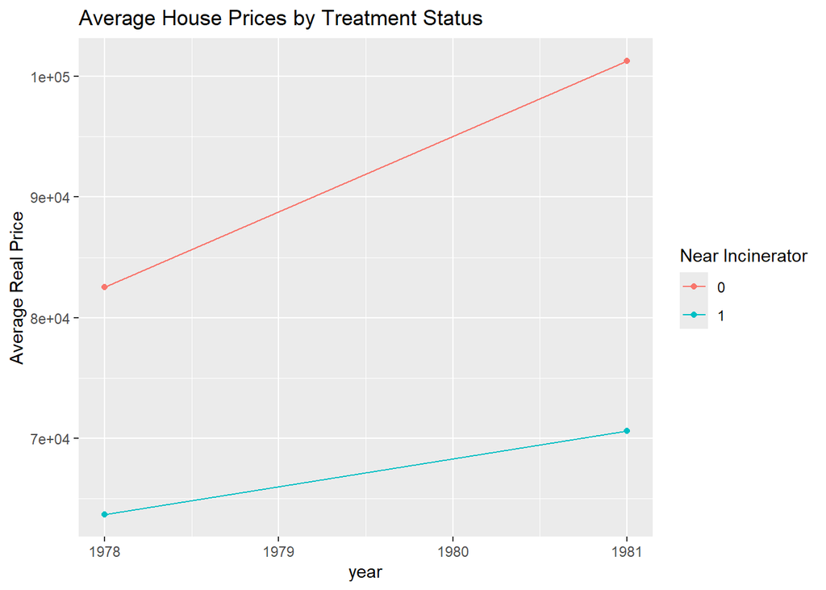

```r
df %>%
  group_by(year, nearinc) %>%
  summarise(
    mean_price = mean(rprice, na.rm = TRUE),
    .groups = "drop"
  ) %>%
  ggplot(aes(x = year, y = mean_price, color = factor(nearinc))) +
  geom_line() +
  geom_point() +
  labs(
    color = "Near Incinerator",
    title = "Average House Prices by Treatment Status",
    y = "Average Real Price"
  )
```

# Baseline Difference-in-Differences model

The standard DiD regression is:

price = β0 + β1 nearinc + β2 post + β3 (nearinc × post) + u

The coefficient of interest is **β3**, which measures the causal effect of being near the incinerator after its announcement.

```r
did_model1 <- lm(
  rprice ~ nearinc + post + did,
  data = df
)
```

# DiD model with housing controls

Housing characteristics may influence price levels. We therefore add controls such as:

- house size (`larea`)
- land size (`lland`)
- number of rooms
- number of bathrooms

```r
did_model2 <- lm(
  rprice ~ nearinc + post + did + larea + lland + rooms + baths,
  data = df
)
```

# Log price specification

Housing prices are often analyzed in logs so coefficients can be interpreted as percentage effects.

```r
df <- df %>%
  mutate(
    lprice = log(rprice)
  )

did_model3 <- lm(
  lprice ~ nearinc + post + did + larea + lland + rooms + baths,
  data = df
)
```

# Model comparison

We present all models together for easier comparison.

```r
modelsummary(
  list(
    "DiD baseline" = did_model1,
    "DiD with controls" = did_model2,
    "Log price model" = did_model3
  ),
  stars = c("*" = .10, "**" = .05, "***" = .01),
  output = "markdown"
)
```

|  | DiD baseline | DiD with controls | Log price model |
| --- | --- | --- | --- |
| (Intercept) | 82517.228*** | -280849.088*** | 7.375*** |
|  | (2726.910) | (37661.163) | (0.394) |
| nearinc | -18824.370*** | 9224.102** | -0.010 |
|  | (4875.322) | (4206.507) | (0.044) |
| post | 18790.286*** | 16494.070*** | 0.168*** |
|  | (4050.065) | (2907.737) | (0.030) |
| did | -11863.903 | -13445.537** | -0.078 |
|  | (7456.646) | (5283.731) | (0.055) |
| larea |  | 27649.063*** | 0.277*** |
|  |  | (5177.223) | (0.054) |
| lland |  | 9225.346*** | 0.099*** |
|  |  | (2016.050) | (0.021) |
| rooms |  | 2526.942 | 0.036** |
|  |  | (1719.955) | (0.018) |
| baths |  | 14726.964*** | 0.196*** |
|  |  | (2448.151) | (0.026) |
| Num.Obs. | 321 | 321 | 321 |
| R2 | 0.174 | 0.606 | 0.686 |
| R2 Adj. | 0.166 | 0.597 | 0.679 |
| AIC | 7540.5 | 7310.6 | -51.5 |
| BIC | 7559.3 | 7344.6 | -17.6 |
| Log.Lik. | -3765.229 | -3646.317 | 34.759 |
| F | 22.251 | 68.839 | 97.538 |
| RMSE | 30053.88 | 20750.08 | 0.22 |

* p < 0.1, ** p < 0.05, *** p < 0.01

# Interpreting the DiD coefficient

The coefficient on the interaction term (`did`) measures the **Difference-in-Differences estimate**.

Interpretation:

- If negative and significant: houses near the incinerator lost value after the announcement.
- If close to zero: no measurable effect.
- In the log model: the coefficient approximates a **percentage change in house prices**.

# Assumptions behind DiD

The key identifying assumption is the **parallel trends assumption**:

Without the treatment (the incinerator), housing prices near and far from the site would have evolved similarly over time.

Because the dataset contains only two years, we cannot directly test pre-treatment trends, but we can still check:

- similarity of groups before treatment
- balance in housing characteristics
- visual patterns in price changes

These checks help assess whether the DiD design is credible.